# Least absolute shrinkage and selection operator - LASSO

## Optimización no lineal con restricciones de desigualdad

Para $f,g_1,\ldots , g_p,h_1,\ldots,h_q:\mathbb{X} \to\mathbb{R}$, con $\mathbb{X}\subset \mathbb{R}^n$ convexo, queremos resolver el problema de optimización

$$ \underset{\pmb{x}}{\arg \min}\,\left\{ f(\pmb{x}) \,:\, g_i(\pmb{x})\leq 0,\, h_j(\pmb{x})=0 \text{ para }\,1\leq i\leq p, \,1\leq j\leq q \right\} $$

Se define la función de Lagrange

$$ L(\pmb{x},\pmb{\mu},\pmb{\lambda})= f(\pmb{x}) + \pmb{\mu}'g(\pmb{x}) + \pmb{\lambda}'h(\pmb{x}) $$

con $g(\pmb{x})=\left( g_1(\pmb{x}),\ldots,g_p(\pmb{x}) \right)',\,h(\pmb{x})=\left( h_1(\pmb{x}),\ldots,h_q(\pmb{x}) \right)'$.

### Teorema de Karush–Kuhn–Tucker (KKT)

(Suficiencia) Si $(\pmb{x}^\star,\pmb{\mu}^\star,\pmb{\lambda}^\star)$ es un punto silla de la función de Lagrange $L(\pmb{x},\pmb{\mu},\pmb{\lambda})$, restringida a $\pmb{\mu}\geq 0$ (desigualdad entrada a entrada) entonces $\pmb{x}^\star$ resuelve el problema de optimización con restricciones de desigualdad.

(Necesidad) Si $f,g_1,\ldots,g_p,h_1,\ldots,h_p$ son convexas y existe $\pmb{x}_0\in\text{relint}(\mathbb{X})$ tal que $g(\pmb{x}_0 )<0$ entonces para $\pmb{x}^\star$ que resuelva el problema de optimización no lineal con restricciones de desigualdad existe $\pmb{\mu}^\star,\pmb{\lambda}^\star$ que satisafcen $\pmb{\mu}^\star\geq 0$ y $(\pmb{x}^\star,\pmb{\mu}^\star,\pmb{\lambda}^\star)$ es un punto silla de $L$.

El problema de optimización para encontrar el punto silla de $L$ es llamado el problema dual, mientras que el problema de optimización original es llamado el problema primal.

### Condiciones de Karush–Kuhn–Tucker (KKT)

Para resolver el problema dual basta que se satisfagan las condiciones

1) (Estacionariedad) $\pmb{0}=\nabla f(\pmb{x}^\star) + \sum_{i=1}^p \mu_i \nabla g_i(\pmb{x}^\star) + \sum_{j=1}^q \lambda_j \nabla h_j(\pmb{x}^\star) $.

2) (Flacidez complementaria) $\mu_ig_i(\pmb{x}^\star)=0$ para todo $1\leq i \leq p $.

3) (Viabilidad primal) $g_i(\pmb{x}^\star)\leq 0$ para todo $1\leq i \leq p $ y $h_j(\pmb{x}^\star)= 0$ para todo $1\leq j \leq q $ .

4) (Viabilidad dual) $\mu_i\geq 0$ para todo $1\leq i \leq p $.

## LASSO

El problema de optimización para LASSO está dado por

$$ \underset{ \pmb{\beta}\in\mathbb{R}^p }{\min}\left\{ \frac{1}{2n}\| \pmb{y}-\hat{\pmb{X}}\pmb{\beta} \|^2_2 + \lambda \| \pmb{\beta} \|_1 \right\} $$

Podemos ver tal problema como un con restricciones de desigualdad por lo que ibtenemos el problema alterno

$$ \underset{ \pmb{\beta}\in\mathbb{R}^p }{\min}\,\left\{ \frac{1}{2n}\| \pmb{y}-\hat{\pmb{X}}\pmb{\beta} \|^2_2 \,:\, \| \pmb{\beta} \|_1 \leq t \right\} $$

Las conidición de estacionariedad de KKT está dada entonces por

$$ 0 = \frac{\partial}{\partial \beta_j}\left( \frac{1}{2n}\sum_{i=1}^n \left(y_i- \pmb{x}_i'\pmb{\beta} \right)^2 + \lambda \sum_{k=1}^p |\beta_k| \right) $$

donde las parciales del valor absoluto deben ser interpretadas como sub-gradientes.

Se sigue que el óptimo $\hat{\pmb{\beta}}$ satisface

\begin{align*} 0 & = -\frac{1}{n}\sum_{i=1}^n x_{i,j}\left(y_i- \pmb{x}_i'\hat{\pmb{\beta}} \right) + \lambda s(\hat{\beta}_j) \\ & = -\frac{1}{n} \hat{\pmb{x}}_j' \left(\pmb{y}- \hat{\pmb{X}}\hat{\pmb{\beta}} \right) + \lambda s(\hat{\beta}_j) \end{align*}

con $\hat{\pmb{x}}_j$ la $j$-ésima columna de $\hat{\pmb{X}}$ y

$$ s(\beta)= \begin{cases} \text{sign}(\beta) & \text{ si }\beta\neq 0, \\ v\in [-1,1] \text{ arbitrario} & \text{ si }\beta=0. \end{cases} $$

Observamos que debemos de tener que si $\hat{\beta}_j\neq 0$ entonces

$$ \frac{1}{n}\left| \langle \hat{\pmb{x}}_j\,,\, \pmb{y}- \hat{\pmb{X}}\hat{\pmb{\beta}} \rangle \right| = \lambda $$

mientras que si $\hat{\beta}_j = 0$ entonces

$$ \frac{1}{n}\left| \langle \hat{\pmb{x}}_j\,,\, \pmb{y}- \hat{\pmb{X}}\hat{\pmb{\beta}} \rangle \right| \leq \lambda $$

Definimos $A(\lambda)=\left\{ j \,:\, \hat{\beta}_j(\lambda) \neq 0 \right\}$ y observamos que si para $\lambda_1<\lambda_2$ se tiene que $A(\lambda_1)=A(\lambda_2)$ y denotamos $\hat{\pmb{X}}_A$ a la matriz con columnas, en orden, $ \hat{\pmb{x}}_j$ para $j\in A$, y $\pmb{0}$ desde la $|A|$-ésima columna hasta $p$, y finalmente $\pmb{s}_A= \left( s_{\sigma(1)},\ldots,s_{\sigma(|A|)} \right)$ con $\sigma$ la permutación correspondiente al orden en $A$; entonces

\begin{align*} \hat{\pmb{X}}'_A\left( \pmb{y} - \hat{\pmb{X}}\hat{\pmb{\beta}}(\lambda_1)\right)&=n\pmb{s}_A\lambda_1 \\ \hat{\pmb{X}}'_A\left( \pmb{y} - \hat{\pmb{X}}\hat{\pmb{\beta}}(\lambda_2)\right)&=n\pmb{s}_A\lambda_2 \end{align*}

entonces

$$ \hat{\pmb{\beta}}(\lambda_1)- \hat{\pmb{\beta}}(\lambda_2) = n(\lambda_2-\lambda_1)s_A $$

**Regresión least-angle (LAR)**

1) Estandarizamos la matriz de predictores para que tenga columnas con media cero y norma uno. Inicializamos el vector de residuos $\pmb{r}_0=\pmb{y}-\bar{y}\pmb{1}$ y $\pmb{\beta}^{(0)}=\pmb{0}$.

2) Encontramos la columna de predictores $\hat{\pmb{x}}_j^\star$ más correlacionada con $\pmb{r}_0$ en el sentido de que $$ j^\star = \underset{j}{\arg \max} \frac{1}{n}\left| \langle \hat{\pmb{x}}_j\,,\, \pmb{r}_0 \rangle \right| $$ Guardamos al valor que maximiza tal correlación como $\lambda_0$ e inicilizamos el cojunto de columnas de covariables activas $\pmb{A}=\left\{ j^\star \right\}$ y la matriz $\pmb{M}_A$ la matriz que consiste de la columna $\hat{\pmb{x}}_j^\star$.

3) Para $k=1,\ldots , K$ realizamos:

3.1) Sea $\pmb{\delta} = \frac{1}{\lambda_{k-1}}( \pmb{M}_A'\pmb{M}_A )^{-1} \pmb{M}_a \pmb{r}_{k-1}$ y sea $\pmb{\Delta}$ un vector con $p$ entradas tales que $\pmb{\Delta}_{1:|A|}=\pmb{\delta}$ y $\pmb{\Delta}_{(|A|+1):p}=\pmb{0}$.

3.2) Sea la recta auxiliar $\pmb{\beta}(\lambda)=\pmb{\beta}^{(k-1)}+(\lambda_{k-1}-\lambda)\pmb{\Delta}$ y $\pmb{r}(\lambda)= \pmb{y} - -\hat{\pmb{X}} \pmb{\beta}(\lambda)=\pmb{r}_{k-1} -(\lambda_{k-1}-\lambda)\pmb{M}_A\pmb{\delta}$.

3.3) Para $l\in \left\{1,\ldots,p\right\}\setminus A$ definimos $\hat{\lambda}_l = \underset{\lambda}{\min}\left\{ \lambda \,:\, \frac{1}{n}\left| \langle \hat{\pmb{x}}_l\,,\, \pmb{r}(\lambda) \rangle \right| = \lambda \right\}$ y tomamos $j^\star = \underset{l}{\arg \min} \hat{\lambda}_l$.

3.4) Actualizamos $A=A\cup\left\{ j^\star \right\}$, $\lambda_k = \hat{\lambda}_{j^\star}$, $\pmb{\beta}^{k}=\pmb{\beta}(\lambda_k)= \pmb{\beta}^{(k-1)} + (\lambda_{k-1} -\lambda_k)\pmb{\Delta} $ y $\pmb{r}_k=\pmb{y}-\hat{\pmb{X}}\pmb{\beta}^{k}$.

4) Regresamos $\left\{ \lambda_k,\pmb{\beta}^{(k)} \right\}_{k=1}^K$

### Ejemplo datos de diabetes

```python
# Cargamos datos de diabete
X, y = datasets.load_diabetes(return_X_y=True)
```

```python
n=len(y)
n
```

```
442
```

```python
p=len(X[0])
p
```

```
10
```

```python
# Corremos el modelo enn scikit-learn
lambdas, _, coefs = linear_model.lars_path(X, y, method="lasso", verbose=True)
```

```
Computing regularization path using the LARS ...
.
```

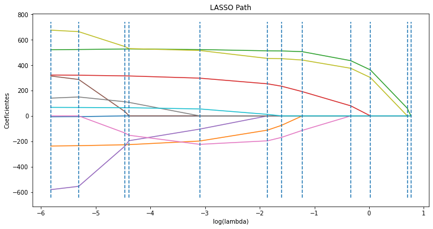

```python
p1[0].figure
```

```python
xx = np.sum(np.abs(coefs.T), axis=1)
xx /= xx[-1]
```

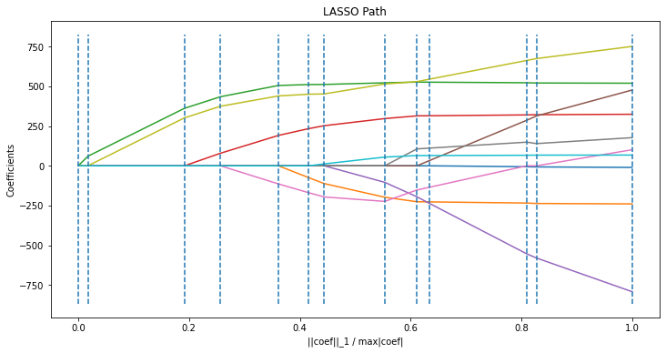

```python
p2[0].figure
```

### Función conjugada

Dada $f:\mathbb{R}^n\to\mathbb{R}$ se define su conjugada $f^\star:\mathbb{R}^n\to\mathbb{R}$ comoo

$$ f^\star(\pmb{y}) = \underset{\pmb{x}}{\max}\pmb{y}'\pmb{x}-f(\pmb{x}) $$

Bajo las condiciones KKT el óptimo se puede encontrar resolviendo

$$ \underset{\pmb{x}}{\min}\left\{ f(x) + \sum_{i=1}^p \mu_i^\star g_i(\pmb{x}) + \sum_{j=1}^q \lambda_j^\star h_j(\pmb{x}) \right\} $$

**Propiedades**

1) Si $f(\pmb{u},\pmb{v})=f_1(\pmb{u})+f_2(\pmb{v})$ entonces $f^\star(\pmb{w},\pmb{z})=f_1^\star(\pmb{w}),f_2^\star(\pmb{z})$.

2) Si $\alpha\in\mathbb{R}$ y $g(\pmb{x})=\alpha f(\pmb{x})$ entonces $g^\star(\pmb{y})=\alpha f^\star\left(\alpha^{-1} \pmb{y} \right)$.

Por ejemplo si queremos minimizar

$$ \underset{\pmb{x}}{\min}\left\{ f(x) \,:\, \pmb{a}'\pmb{x} = b \right\} $$

entonces bajo las condiciones KKT el óptimo se puede encontrar resolviendo

\begin{align*} \underset{\pmb{x}}{\min}\left\{ f(x) + \lambda^\star \left(b-\pmb{a}'\pmb{x} \right) \right\} & = \lambda^\star b -\underset{x}{\max}\left\{ \lambda^\star \pmb{a}'\pmb{x} - f(x) \right\} = \lambda^\star b - f^\star(\lambda^\star\pmb{a}) \end{align*}

donde $\lambda^\star$ es el óptimo del problema dual

$$ \underset{\lambda}{\max} \left\{ \lambda b - f^\star(\lambda\pmb{a}) \right\}. $$

Si $f$ es convexa basta resolver $\nabla f(\pmb{x})=\lambda \pmb{a}$.